# Projet R

Thomas Meresse - Sayqin Rustamli - Éric Valette

2025-01-09

# Présentation du projet

Nous avons choisi de réaliser un projet lié au domaine de la finance.

Plus précisément, notre objectif est de créer un rapport financier généré automatiquement, en nous basant sur les cryptomonnaies les plus populaires pour effectuer nos analyses, principalement sous forme de graphiques (et des analyses très basiques). Le rapport final sera un PDF produit automatiquement dès l’exécution du code.

Il y aura par exemple :

- Le cours des 6 coins ayant les meilleurs rendements, sur les 365 derniers jours
- Le cours du bitcoin sur les 15 derniers jours
- Une comparaison graphique entre un portefeuille diversifié et un portefeuille unique

# Présentation du projet

Pour ce faire, nous allons utiliser un API sur l’univers financier, qui fournit des données très détaillées et gratuites (dans une certaine mesure). Cet API, c’est CoinGecko.

[figure not shown]

Cet API présente plusieurs avantages :

- Plan gratuit (10 000 requête par mois)
- Documentation bien détaillée et compréhensive

# Le code

On commence par charger les librairies dont on aura besoin

```r
rm(list = ls())

library(tinytex)        #Pour le pdf final en latex

library(httr2)          #Pour les requêtes API

library(tidyverse)      #Pour la manipulation des données

library(lubridate)      #Pour la manipulation des dates

library(corrplot)       #Pour le plot des corrélation
```

ici, on fait le choix de httr2 au lieu de httr, car la version n°2 est plus facile et intuitive.

On peut par ailleurs, définir notre clé API pour la suite.

```r
cleAPI <- ' la clé API '
```

La clé n’est pas affichée pour des raisons de confidentialité, mais le chunk avec la vrai clé est bien présent dans le code (il n’est juste pas affiché).

# Le code

Ici, nous avons utilisé un échantillon des 30 cryptomonnaies les plus populaires.

```r
setwd('/Users/thomasmeresse/Desktop/R_entrainement/dataset')

crypto <- read.csv('top_30_cryptos.csv')

head(crypto, 5)
```

```
##   Rank     Name      API_ID
## 1    1  Bitcoin     bitcoin
## 2    2 Ethereum    ethereum
## 3    3   Tether      tether
## 4    4      BNB binancecoin
## 5    5 USD Coin    usd-coin
```

```r
crypto <- crypto[-15,]          #Similaire au bitcoin

crypto <- crypto[-23,]          #Similaire au bitcoin
```

# La boucle for

```r
urlbase <- 'https://api.coingecko.com/api/v3/coins/'


urlfin <- '/market_chart?vs_currency=eur&days=365&interval=daily'


df <- data.frame()
```

Voici l’url de base de l’API de coingecko, c’est le point de départ. Il est découpé en deux partie, car l’ID du coin doit se trouver entre les deux.

# Le début de la boucle for

```r
for (i in 1:nrow(crypto)) {


  url <- paste0(urlbase, crypto[i, 3], urlfin)


  print(url)


  req <- request(url) %>% req_headers('x-cg-demo-api-key' = cleAPI)


  reponse <- req_perform(req)


  donnee <- reponse %>% resp_body_json()
```

```r
glimpse(donnee)
```

[output not shown]

[output cut: 843 more lines]

[output not shown]

# Fin de la boucle for

```r
  Prix <- donnee %>% pluck('prices') %>% map_dfr(function(x)

      tibble(Prix = x %>% pluck(2))) %>%

      mutate(Jours = row_number())

  Volumes <- donnee %>% pluck('total_volumes') %>% map_dfr(function(x)

      tibble(Volumes = x %>% pluck(2))) %>%

      mutate(Jours = row_number())

  Capitalisation <- donnee %>% pluck('market_caps') %>% map_dfr(function(x)

      tibble(Capitalisation = x %>% pluck(2))) %>%

      mutate(Jours = row_number())


  nv_df1 <- left_join(Prix, Volumes, by = 'Jours')

  nv_df <- left_join(nv_df1, Capitalisation, by = 'Jours') %>%

      mutate(ID = crypto[i, 3])


  nv_df <- nv_df %>% mutate(Rendement = (Prix[Jours == max(Jours)] - Prix[Jours == min(Jours)])

                            / Prix[Jours == min(Jours)])

  df <- bind_rows(df, nv_df)

}
```

# Le data frame final

```r
dim(df)
```

```
## [1] 10248     6
```

```r
head(df)
```

```
##       Prix Jours     Volumes Capitalisation      ID Rendement
## 1 39122.52     1 41876420339   764669480252 bitcoin  1.351002
## 2 39081.07     2 17716846311   765413030638 bitcoin  1.351002
## 3 38190.21     3 15503197379   751728074199 bitcoin  1.351002
## 4 38908.90     4 20679492661   763009829958 bitcoin  1.351002
## 5 39668.76     5 20247282080   777614406834 bitcoin  1.351002
## 6 39242.29     6 19567983377   769011178460 bitcoin  1.351002
```

# Nettoyage du data frame

```r
suppression <- df %>%

  filter(Prix < 1) %>%

  pull(ID)

df <- df %>% filter(!ID %in% suppression)

Rendem <- df %>% group_by(ID) %>% summarise(C = first(Rendement)) %>% arrange(desc(C)) %>%

    slice(1:6)

df <- df %>% filter(ID %in% Rendem$ID)
```

- On va supprimer les cryptomonnaie qui ont un prix inférieur à 1, car elles biaisent les rendements.
- On va prendre uniquement les 6 coins qui ont les meilleurs rendements

# Évolution des 6 meilleurs cryptomonnaies sur 365 jours.

Ce sera notre premier plot.

```r
df %>%

  ggplot(aes(x = Jours, y = Prix, color = ID)) +

  geom_line(show.legend = F) +

  geom_smooth(method = 'lm', se = F, size = 0.4, show.legend = F) +

  facet_wrap(~ ID, scales = 'free_y') +

  labs(title = 'Cours des coins avec les meilleurs rendements, sur les 365 derniers jours') +

  theme_classic()
```

# Évolution des 6 meilleurs cryptomonnaies sur 365 jours.

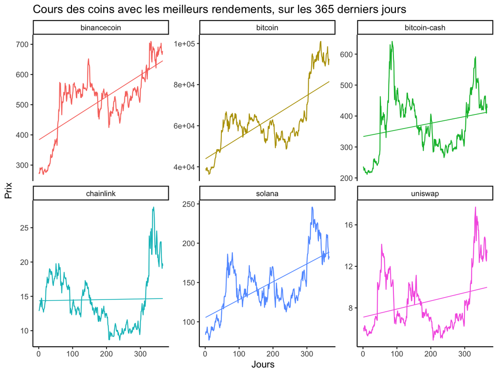

[figure not shown]

# Évolution d’un seul actif sur une période plus courte.

Maintenant, voici un aperçu de l’évolution des prix du bitcoin sur les 15 derniers jours. Avec une droite de tendance.

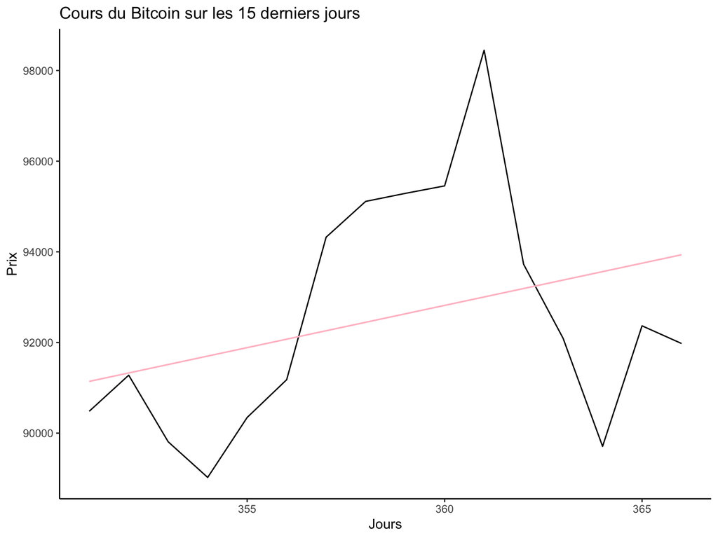

```r
bitcoin <- df[df$ID == 'bitcoin',]

bitcoin <- bitcoin %>% filter(Jours > 350)

bitcoin %>% ggplot(aes(x = Jours, y = Prix)) +

  geom_line(show.legend = F) +

  labs(title = 'Cours du Bitcoin sur les 15 derniers jours') +

  geom_smooth(method = 'lm', se = F, show.legend = F, color = 'pink', size = 0.6) +

  theme_classic()
```

# Comparaison entre un portefeuille diversifié et un portefeuille unique.

Ensuite, nous avons fait un graphique qui compare les rendements sur un an entre un portefeuille diversifié et un portefeuille unique. En supposant que l’on investit 100 euros.

Encore une fois, tout est automatique donc les données utilisée un jour, peuvent changer le lendemain.

Pour ce faire :

```r
head(Rendem)
```

```
## # A tibble: 6 × 2
##   ID               C
##   <chr>        <dbl>
## 1 binancecoin  1.50
## 2 bitcoin      1.35
## 3 uniswap      1.21
## 4 solana       1.17
## 5 bitcoin-cash 0.803
## 6 chainlink    0.511
```

```r
h <- Rendem %>% filter(C == max(C)) %>% pull(ID)

Meilleur <- df[df$ID == h,]

g <- Rendem %>% slice_max(order_by = C, n = 5)

Meilleur_5 <- df %>% filter(ID %in% g$ID)
```

# Comparaison entre un portefeuille diversifié et un portefeuille unique.

```r
Meilleur <- Meilleur %>%

    mutate(Rendement_journalier = (Prix - lag(Prix))/lag(Prix)) %>%

    select(Rendement_journalier, Jours) %>%

    arrange(Jours)

Meilleur$Rendement_journalier[1] <- 0

Meilleur_5 <- Meilleur_5 %>%

    mutate(Rendement_journalier = (Prix - lag(Prix))/lag(Prix)) %>%

    group_by(Jours) %>%

    mutate(Diversifie = sum(Rendement_journalier * 0.2, na.rm = TRUE))

Meilleur_5 <- Meilleur_5 %>% filter(Diversifie < 1) %>%

    distinct(Jours, .keep_all = TRUE) %>%

    select(Jours, Diversifie) %>%

    arrange(Jours)
```

# Comparaison entre un portefeuille diversifié et un portefeuille unique.

Maintenant que l’on a les rendements, il ne reste plus qu’à calculer les sommes que l’on obtiendrait en un an en investissant 100€. On doit faire cela pour chaque jour, pour pouvoir ensuite le représenter graphiquement.

```r
Meilleur_5$Valeur_Portefeuille_5 <- 100

for (i in 2:nrow(Meilleur_5)) {

    Meilleur_5$Valeur_Portefeuille_5[i] <- Meilleur_5$Valeur_Portefeuille_5[i-1] * (1 + Meilleur_5$Diversifie[i])}
```

```r
Meilleur$Valeur_portefeuille <- 100

for (i in 2:nrow(Meilleur)) {

    Meilleur$Valeur_portefeuille[i] <- Meilleur$Valeur_portefeuille[i-1] * (1+ Meilleur$Rendement_journalier[i])}
```

```r
#Par exemple pour les 10 premiers jours.

head(Meilleur$Valeur_portefeuille, 10)
```

[output not shown]

# Graphiquement

La ligne bleue correspond au portefeuille diversifié comprenant **binancecoin**, **bitcoin**, **uniswap**, **solana**, **bitcoin-cash**, les coins aux meilleurs rendement. La ligne rouge correspond au portefeuille unique comprenant **binancecoin**.

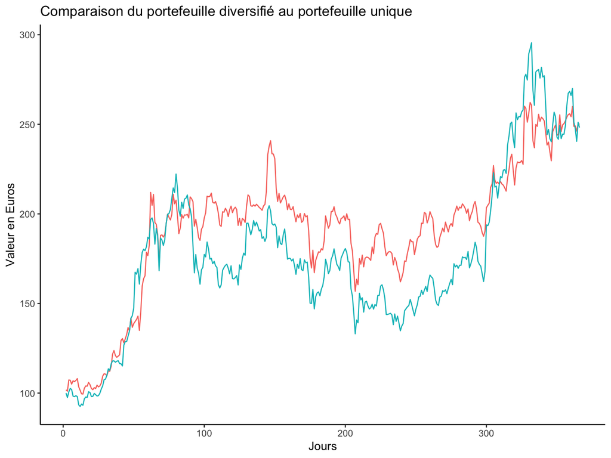

```r
Comparaison %>% ggplot(aes(x = Jours, y = Valeur, color = Portefeuille)) +

    geom_line(show.legend = F) +

    labs(title = 'Comparaison du portefeuille diversifié au portefeuille unique',

         y = 'Valeur en Euros') +

    theme_classic()
```

# Des indicateurs plus classiques

Par exemple sur les rendements à un an, un mois, une semaine.

```r
#Rendement à un an

Rendement_an <- df %>% filter(ID %in% g$ID) %>%

    group_by(ID) %>%

    summarise(Rendement = (Prix[365] - Prix[1])/ Prix[1]) %>%

    mutate(Periode = 'Année')
```

```r
Rendement_combines <- bind_rows(Rendement_an, Rendement_mois, Rendement_semaine)
```

# Graphiquement

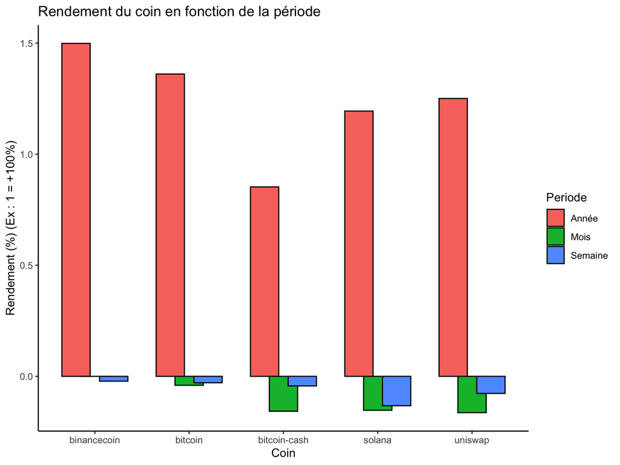

```r
Rendement_combines %>% ggplot(aes(x = ID, y = Rendement, fill = Periode)) +

  geom_bar(stat = "identity", position = position_dodge(width = 0.6), color = 'black') +

  labs(title = 'Rendement du coin en fonction de la période', x = 'Coin', y = 'Rendement (%) (Ex : 1 = +100%)') +

  theme_classic()
```

# La volatilité

```r
#Sur un an

Volatilite_an <- df %>% filter(ID %in% g$ID) %>%

    group_by(ID) %>%

    mutate(Rendement_journalier = (Prix - lag(Prix)) / lag(Prix)) %>%

    summarise(Volatilite = sd(Rendement_journalier, na.rm = TRUE)) %>%

    mutate(Periode = "Année")
```

```r
Volatilite_combinee <- bind_rows(Volatilite_an, Volatilite_mois, Volatilite_semaine)
```

# Graphiquement

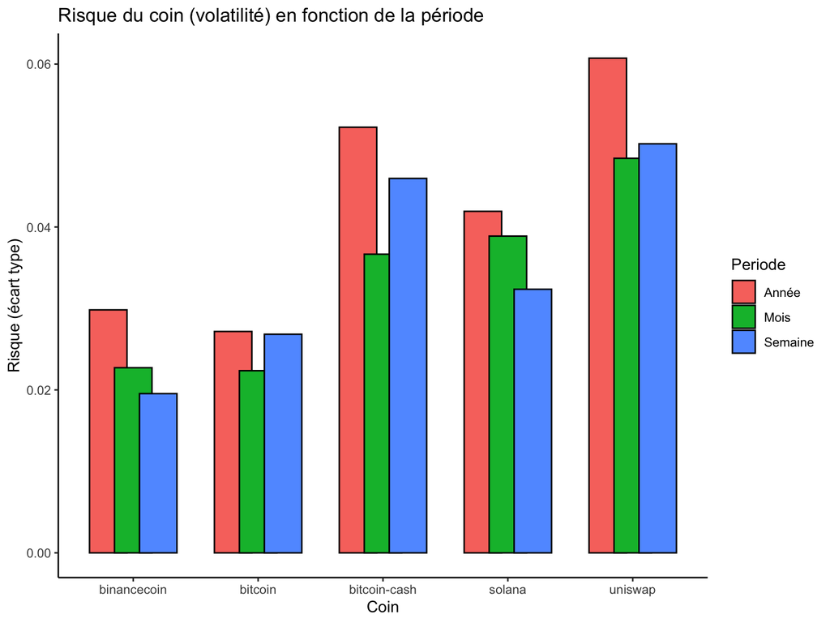

```r
Volatilite_combinee %>% ggplot(aes(x = ID, y = Volatilite, fill = Periode)) +

    geom_bar(stat = "identity", position = position_dodge(width = 0.6), color = 'black') +

    labs(title = 'Risque du coin (volatilité) en fonction de la période', x = 'Coin', y = 'Risque (écart type)') +

    theme_classic()
```

# Une autre mesure graphique de la volatilité

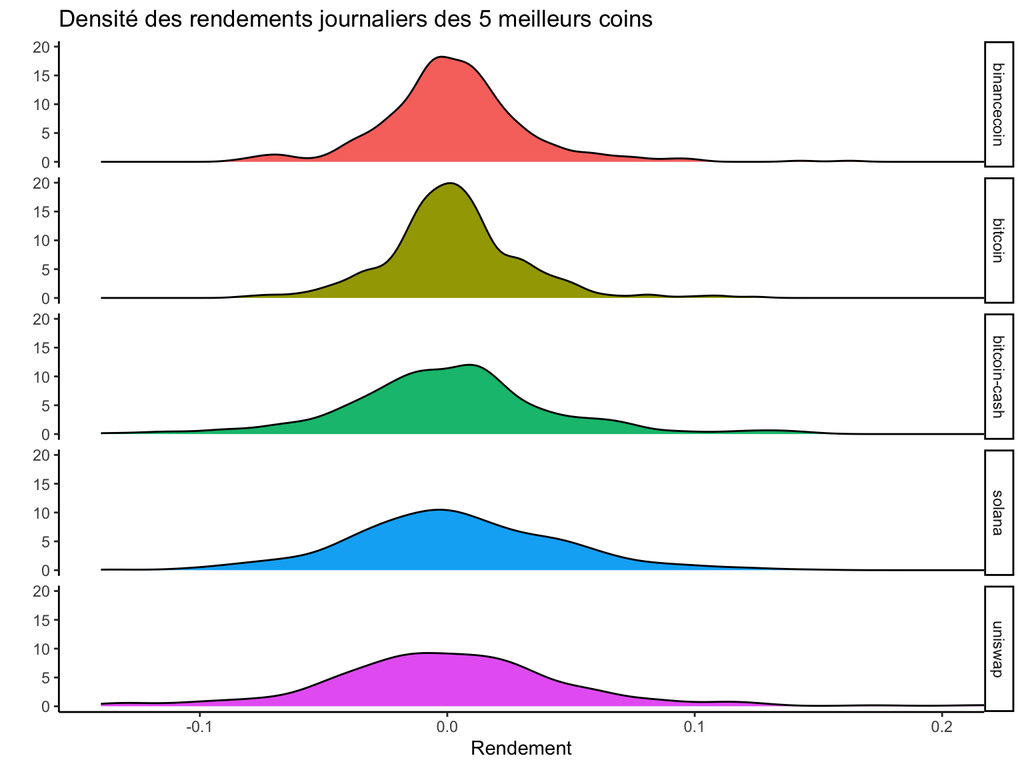

```r
Densi %>% ggplot(aes(x = Rendement, fill = ID)) +

    geom_density(show.legend = F) +

    coord_cartesian(xlim = c(min(Densi$Rendement), 0.2)) +

    facet_grid(ID ~.) +

    labs(title = 'Densité des rendements journaliers des 5 meilleurs coins', y = '') +

    theme_classic()
```

# Sortie finale

Enfin, toutes ces données et graphiques sont généré automatiquement en pdf à l’éxécution du code. Mais ici c’est pas le cas car on a changé la méthode de sortie pour avoir un diaporama et qui affiche le code.

Pour finir, voici une analyse des forces et faiblesses de notre code.

Forces :

- Utilisation des éléments du cours (tidyverse)
- Des graphiques clairs et faciles à comprendre

Faiblesses :

- Les boucles for pour extraire les données, avec un grand nombre d’itération, ça pourrait devenir très long
- Redondance de certaines étapes (répétées plusieurs fois, juste en changeant un argument)